# nNIL phenotype analysis

Jim Holland

2024-11-15

```r
knitr::opts_chunk$set(echo = TRUE)
library(tidyverse)
library(asreml)
```

Read in phenotype data file from many sheets

```r
pheno = readxl::read_xlsx('C:/Users/jholland/Box/nNIL genotype data Jim and Tao/nNIL_data_supplement/File_S07.Phenotype.xlsx', sheet = "tpj14787-sup-0001-File1", guess_max = 30000) |>
  mutate(Env = sub("-[12]$", "", Env),
         Env = as.factor(Env),
         Rep = as.factor(Rep),
         Block = as.factor(Block),
         Geno = as.factor(sub("_", " ", Geno))) #replace the underscore with space to match the Geno coding in SNP data files
```

Summarize data structure

```r
pheno |> group_by(Env, Rep) |>
  summarize(nGLS1 = sum(!is.na(GLS1)),
            nGLS2 = sum(!is.na(GLS2)),
            nSLB1 = sum(!is.na(SLB1)),
            nSLB2 = sum(!is.na(SLB2)),
            nNLB1 = sum(!is.na(NLB1)),
            nNLB2 = sum(!is.na(NLB2)))
```

[output not shown]

```
## # A tibble: 12 × 8
## # Groups:   Env [9]
##    Env      Rep   nGLS1 nGLS2 nSLB1 nSLB2 nNLB1 nNLB2
##    <fct>    <fct> <int> <int> <int> <int> <int> <int>
##  1 GLS-2014 1      1240  1280     0     0     0     0
##  2 GLS-2016 1      1284  1300     0     0     0     0
##  3 GLS-2016 2      1277  1059     0     0     0     0
##  4 GLS-2017 1      1272  1266     0     0     0     0
##  5 NLB-2015 1         0     0     0     0   959  1079
##  6 NLB-2016 1         0     0     0     0  1280  1281
##  7 NLB-2016 2         0     0     0     0  1060  1107
##  8 NLB-2018 1         0     0     0     0  1246  1250
##  9 SLB-2014 1         0     0  1102   533     0     0
## 10 SLB-2014 2         0     0  1235  1231     0     0
## 11 SLB-2015 1         0     0  1287  1293     0     0
## 12 SLB-2016 1         0     0  1293  1291     0     0
```

Check distributions for each trait

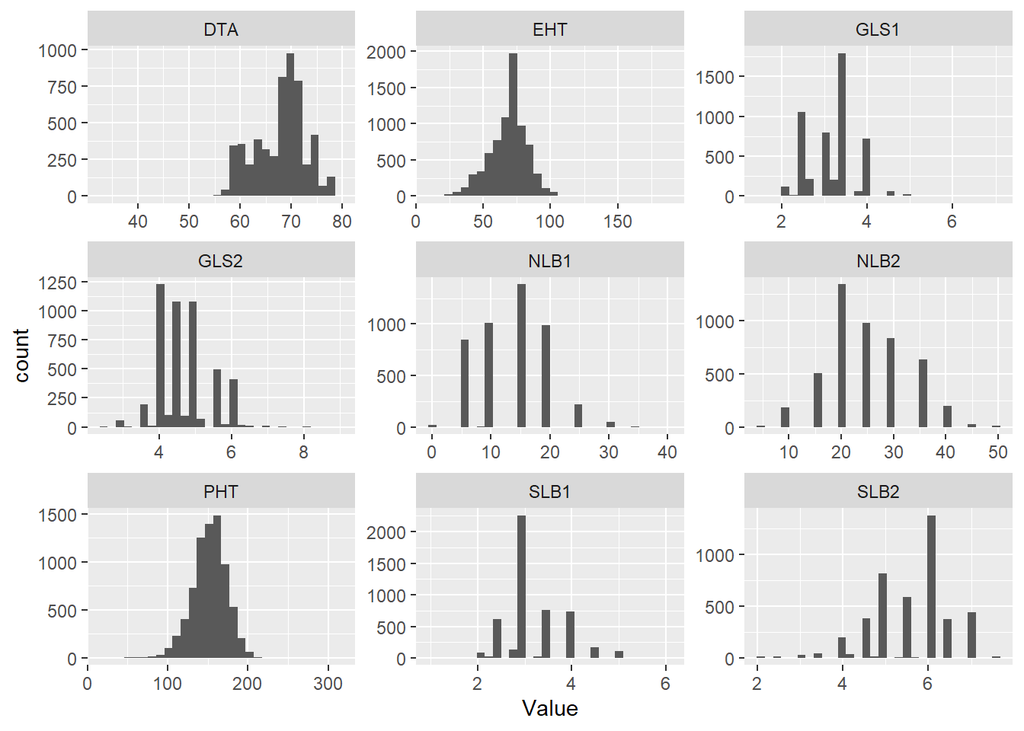

```r
pheno.long = pheno |> pivot_longer(cols = c("DTA", "EHT", "PHT", "GLS1", "GLS2", "NLB1", "NLB2", "SLB1", "SLB2"), names_to = "Trait", values_to = "Value")

ggplot(pheno.long, aes(x = Value)) + geom_histogram() +
  facet_wrap(facets = vars(Trait), scales = "free")
```

```r
summary(pheno$DTA)
```

```
##    Min. 1st Qu.  Median    Mean 3rd Qu.    Max.    NA's
##   33.00   64.00   69.00   67.97   71.00   79.00   10180
```

```r
pheno |> slice_min(order_by = DTA, n = 5, with_ties = F) |>
  select(Env, Plot, Geno, DTA, EHT, PHT)
```

```
## # A tibble: 5 × 6
##   Env       Plot Geno                  DTA   EHT   PHT
##   <fct>    <dbl> <fct>               <dbl> <dbl> <dbl>
## 1 NLB-2015 30459 CML52/B73 NIL-1003     33    65   135
## 2 NLB-2015 31039 NC358/B73 NIL-1088     33    35   100
## 3 SLB-2014 26084 NC358/B73 NIL-1189B    39    69   134
## 4 SLB-2014 26755 CML52/B73 NIL-1204     41    70   143
## 5 SLB-2015 25224 CML247/B73 NIL-1115    55    70   140
```

Check these against their other reps:

```r
pheno |> filter(Geno %in% c("CML52/B73_NIL-1003", "NC358/B73_NIL-1088", "NC358/B73_NIL-1189B", "CML52/B73_NIL-1204", "CML247/B73_NIL-1115")) |>
  select(Env, Plot, Geno, DTA, EHT, PHT) |>
    arrange(Geno)
```

```
## # A tibble: 0 × 6
## # ℹ 6 variables: Env <fct>, Plot <dbl>, Geno <fct>, DTA <dbl>, EHT <dbl>,
## #   PHT <dbl>
```

DTA values < 55 appear to be incorrect, drop them

```r
pheno = pheno |> mutate(DTA = ifelse(DTA < 55, NA, DTA))
```

make data subsets for each disease, they were done in separate trials

```r
gls = pheno |>
  filter(grepl("GLS", Env)) |>
  arrange(Env)

nlb = pheno |>
  filter(grepl("NLB", Env))

slb = pheno |>
  filter(grepl("SLB", Env))
```

Fit multivariate model for repeated measures of disease, first with genotypes as random effects to estimate genetic variances, correlations, and heritabilities for the two disease scores.

Make a function to fit the multivariate model with geno as random effect

```r
rand.multi.mod = function(trt, dat){
  print("Geno as random effect")
  print(trt)
  fixed.part = as.formula(paste0("cbind(", trt, "1, ", trt, "2) ~ trait + trait:Env"))
  mod = asreml(fixed = fixed.part,
                random = ~  at(trait):Block:Rep:Env +  us(trait):Geno , # + at(trait):Geno:Env adding GxE to model prevents convergence even with 50 iterations
                residual = ~ dsum(~ units:us(trait) | Env),
                data = dat,
                workspace = '16gb',
                maxiter = 50)
  print(summary(mod))

  return(mod)
}
```

# GLS

fit the model to GLS

```r
glsmod = rand.multi.mod("GLS", gls)
```

```
## [1] "Geno as random effect"
## [1] "GLS"
## ASReml Version 4.2 02/04/2025 14:50:36
##           LogLik        Sigma2     DF     wall
##  1      3222.868           1.0  10484   14:50:42
##  2      3449.691           1.0  10484   14:50:42
##  3      3656.269           1.0  10484   14:50:42
##  4      3742.276           1.0  10484   14:50:42
##  5      3758.126           1.0  10484   14:50:42
##  6      3758.420           1.0  10484   14:50:42
##  7      3758.423           1.0  10484   14:50:42
## $call
## asreml(fixed = fixed.part, random = ~at(trait):Block:Rep:Env +
##     us(trait):Geno, residual = ~dsum(~units:us(trait) | Env),
##     data = dat, workspace = "16gb", maxiter = 50)
##
## $loglik
## [1] 3758.423
##
## $nedf
## [1] 10484
##
## $sigma
## [1] 1
##
## $varcomp
##                                  component   std.error   z.ratio bound %ch
## at(trait, 'GLS1'):Block:Rep:Env 0.03487400 0.003889644  8.965859     P 0.0
## at(trait, 'GLS2'):Block:Rep:Env 0.08456000 0.009602116  8.806392     P 0.0
## trait:Geno!trait_GLS1:GLS1      0.01862238 0.001804970 10.317278     P 0.0
## trait:Geno!trait_GLS2:GLS1      0.03568448 0.002700389 13.214570     P 0.1
## trait:Geno!trait_GLS2:GLS2      0.08015485 0.005835659 13.735356     P 0.0
## Env_GLS-2014!R                  1.00000000          NA        NA     F 0.0
## Env_GLS-2014!trait_GLS1:GLS1    0.13789034 0.006091626 22.636047     P 0.0
## Env_GLS-2014!trait_GLS2:GLS1    0.08354717 0.006585603 12.686336     P 0.0
## Env_GLS-2014!trait_GLS2:GLS2    0.23664225 0.011130832 21.260068     P 0.0
## Env_GLS-2016!R                  1.00000000          NA        NA     F 0.0
## Env_GLS-2016!trait_GLS1:GLS1    0.12951972 0.004083812 31.715397     P 0.0
## Env_GLS-2016!trait_GLS2:GLS1    0.09760430 0.005072486 19.241904     P 0.0
## Env_GLS-2016!trait_GLS2:GLS2    0.28021980 0.009599372 29.191474     P 0.0
## Env_GLS-2017!R                  1.00000000          NA        NA     F 0.0
## Env_GLS-2017!trait_GLS1:GLS1    0.04592602 0.002423781 18.948093     P 0.0
## Env_GLS-2017!trait_GLS2:GLS1    0.01442624 0.003304227  4.365995     P 0.0
## Env_GLS-2017!trait_GLS2:GLS2    0.15804905 0.008266786 19.118561     P 0.0
##
## $bic
## [1] -7387.24
## attr(,"parameters")
## [1] 14
##
## $aic
## [1] -7488.847
## attr(,"parameters")
## [1] 14
##
## attr(,"class")
## [1] "summary.asreml"
```

```r
summary(glsmod)
```

```
## $call
## asreml(fixed = fixed.part, random = ~at(trait):Block:Rep:Env +
##     us(trait):Geno, residual = ~dsum(~units:us(trait) | Env),
##     data = dat, workspace = "16gb", maxiter = 50)
##
## $loglik
## [1] 3758.423
##
## $nedf
## [1] 10484
##
## $sigma
## [1] 1
##
## $varcomp
##                                  component   std.error   z.ratio bound %ch
## at(trait, 'GLS1'):Block:Rep:Env 0.03487400 0.003889644  8.965859     P 0.0
## at(trait, 'GLS2'):Block:Rep:Env 0.08456000 0.009602116  8.806392     P 0.0
## trait:Geno!trait_GLS1:GLS1      0.01862238 0.001804970 10.317278     P 0.0
## trait:Geno!trait_GLS2:GLS1      0.03568448 0.002700389 13.214570     P 0.1
## trait:Geno!trait_GLS2:GLS2      0.08015485 0.005835659 13.735356     P 0.0
## Env_GLS-2014!R                  1.00000000          NA        NA     F 0.0
## Env_GLS-2014!trait_GLS1:GLS1    0.13789034 0.006091626 22.636047     P 0.0
## Env_GLS-2014!trait_GLS2:GLS1    0.08354717 0.006585603 12.686336     P 0.0
## Env_GLS-2014!trait_GLS2:GLS2    0.23664225 0.011130832 21.260068     P 0.0
## Env_GLS-2016!R                  1.00000000          NA        NA     F 0.0
## Env_GLS-2016!trait_GLS1:GLS1    0.12951972 0.004083812 31.715397     P 0.0
## Env_GLS-2016!trait_GLS2:GLS1    0.09760430 0.005072486 19.241904     P 0.0
## Env_GLS-2016!trait_GLS2:GLS2    0.28021980 0.009599372 29.191474     P 0.0
## Env_GLS-2017!R                  1.00000000          NA        NA     F 0.0
## Env_GLS-2017!trait_GLS1:GLS1    0.04592602 0.002423781 18.948093     P 0.0
## Env_GLS-2017!trait_GLS2:GLS1    0.01442624 0.003304227  4.365995     P 0.0
## Env_GLS-2017!trait_GLS2:GLS2    0.15804905 0.008266786 19.118561     P 0.0
##
## $bic
## [1] -7387.24
## attr(,"parameters")
## [1] 14
##
## $aic
## [1] -7488.847
## attr(,"parameters")
## [1] 14
##
## attr(,"class")
## [1] "summary.asreml"
```

Make a function to extract genotypic and residual variances and correlations for ratings. Also heritability estimates based on squared mean accuracies.

```r
genvarcor = function(trait.name, rand.mod, fixed.part, dat){
  rg = vpredict(rand.mod, rg ~ V4/sqrt(V3*V5))
  Vg_1 = vpredict(rand.mod, Vg_1 ~ V3)
  Vg_2 = vpredict(rand.mod, Vg_2 ~ V5)

  re1 = vpredict(rand.mod, re1 ~ V8/sqrt(V7*V9))
  re2 = vpredict(rand.mod, re2 ~ V12/sqrt(V11*V13))
  re3 = vpredict(rand.mod, re3 ~ V16/sqrt(V15*V17))

  preds = predict(rand.mod, classify = "trait:Geno", average = c("Env", "Rep", "Block"),
                pworkspace = '16gb')

  blups_1 = preds[[1]] |>
  filter(grepl("1$", trait)) |>
  mutate(r2 = 1 - ((std.error^2)/unlist(Vg_1[1,1])))

  h2.1 = mean(blups_1$r2)

  blups_2 = preds[[1]] |>
  filter(grepl("2$", trait)) |>
  mutate(r2 = 1 - ((std.error^2)/unlist(Vg_2[1,1])))

  h2.2 = mean(blups_2$r2)

  #Get BLUPs and accuracy of gls averaged across ratings. Variance of the mean value (rating1+rating2/2) = (1/4)V(Vg_1 + Vg_2 + 2Cov_12)
  preds.mn.list = predict(glsmod, classify = "Geno", average = c("Env", "Rep", "Block", "trait"),
                pworkspace = '16gb')
  blups_mean =  preds.mn.list[[1]]
  Vg_mean = 0.25*(unlist(Vg_1[1,1] + unlist(Vg_2[1,1]) + (2*unlist(vpredict(rand.mod, Covg ~ V4)[1,1]))))

  blups_mean = blups_mean |>
  mutate(r2 = 1 - ((std.error^2)/Vg_mean))

  h2.mean = mean(blups_mean$r2)

  #for comparison, get the Cullis estimator of heritability
  h2_Cull = 1 - ((preds.mn.list[[2]]^2)/(2*Vg_mean))

  h2.df = data.frame(Trait = trait.name, Parameter = c("h2_1", "h2_2", "h2_mean", "h2_Cull"), Estimate = c(h2.1, h2.2, h2.mean, h2_Cull), SE = c(NA, NA, NA, NA))
  row.names(h2.df) = c("h2_1", "h2_2", "h2_mean", "h2_Cull")

  #compile results into a data.frame
  results = rbind(rg, Vg_1, Vg_2, re1, re2, re3)
  results$Parameter = row.names(results)
  results$Trait = trait.name

  results = rbind(results, h2.df)

  return(results)
}
```

Get estimates and results for GLS

```r
fixed.part.gls = as.formula("cbind(GLS1, GLS2) ~ trait + trait:Env")
(results.gls = genvarcor("GLS", glsmod, fixed.part.gls, gls))
```

```
## ASReml Version 4.2 02/04/2025 14:50:44
##           LogLik        Sigma2     DF     wall
##  1      3758.423           1.0  10484   14:50:56
##  2      3758.423           1.0  10484   14:50:56
##  3      3758.423           1.0  10484   14:50:56
## ASReml Version 4.2 02/04/2025 14:51:00
##           LogLik        Sigma2     DF     wall
##  1      3758.423           1.0  10484   14:51:10
##  2      3758.423           1.0  10484   14:51:10
##  3      3758.423           1.0  10484   14:51:10
```

```
##           Estimate          SE Parameter Trait
## rg      0.92362763 0.032233488        rg   GLS
## Vg_1    0.01862238 0.001804970      Vg_1   GLS
## Vg_2    0.08015485 0.005835659      Vg_2   GLS
## re1     0.46250737 0.025602781       re1   GLS
## re2     0.51233210 0.017516858       re2   GLS
## re3     0.16932762 0.035645783       re3   GLS
## h2_1    0.55588952          NA      h2_1   GLS
## h2_2    0.59209171          NA      h2_2   GLS
## h2_mean 0.59877696          NA   h2_mean   GLS
## h2_Cull 0.60127455          NA   h2_Cull   GLS
```

Now treat ratings 1 and 2 as univariate with a rating factor so we can get BLUEs adjusting for rating effect. Missing data patterns differ between ratings 1 and 2 so these adjustments are needed. And we want BLUEs, not BLUPs, for subsequent QTL/GWAS analysis.

```r
gls2 = gls |>
  select(Env, Rep, Block, Geno, Plot, GLS1, GLS2) |>
  pivot_longer(cols = c("GLS1", "GLS2"), names_to = "Rating", values_to = "GLS") |>
  mutate(Rating= as.factor(Rating))
```

Make a function to fit univariate model and get Geno BLUEs across ratings

```r
get.blues = function(trait.name, dat, Rating = T){
  print("Geno as fixed effects")
  print(trait.name)
  fixed.part = as.formula(paste(trait.name, "~ Geno"))
  if (Rating) {random.part = as.formula("~  Env + Block:Rep:Env + Rating:Env + Geno:Env")} else {
    random.part = as.formula("~  Env + Block:Rep:Env + Geno:Env")  }
  mod = asreml(fixed = fixed.part,
                random = random.part ,
                residual = ~ dsum(~ units | Env),
                data = dat,
                workspace = '16gb',
                maxiter = 50)

  #print out the Wald test for fixed effects
  print("")
  print(wald(mod))

  blues.list = predict(mod, classify = "Geno", pworkspace = '16gb', sed = T)
  blues.df = blues.list[[1]] |>
    select(Geno, predicted.value) |>
    filter(Geno != "BBP") #drop the unrelated BBP check line

  blues.sed = blues.list[[3]] #matrix of SED for all pairwise mean comparisons
  blues.sed.vs.b73 = as.matrix(blues.sed)[!blues.df$Geno %in% c("B73", "BBP"), blues.df$Geno == "B73"]
  mean.sed.vs.b73 = mean(blues.sed.vs.b73, na.rm = T)
  sign.diff.05 = 1.96*mean.sed.vs.b73
  b73.mean = blues.df[blues.df$Geno == "B73", "predicted.value"]
  lower.sign = b73.mean - sign.diff.05
  upper.sign = b73.mean + sign.diff.05


  results.df = data.frame(
    Trait = trait.name,
    Parameter = c("Mean_LSD_vs_B73", "B73_mean", "Lower_Sign_Diff", "Upper_Sign_Diff"),
    Estimate = c(sign.diff.05, b73.mean, lower.sign, upper.sign)
  )

  #indicate if a nNIL mean is significantly different than B73
  blues.df[, paste0(trait.name, ".sig.less.B73")] = blues.df$predicted.value < lower.sign
  blues.df[, paste0(trait.name, ".sig.greater.B73")] = blues.df$predicted.value > upper.sign

  colnames(blues.df) = sub("predicted.value", trait.name, colnames(blues.df))

  results.list = list(blues.df, results.df)

  print(str(results.list))
  return(results.list)
  }
```

Get BLUEs across env, rep, block, ratings

```r
gls.blues.list = get.blues("GLS", gls2)
```

```
## [1] "Geno as fixed effects"
## [1] "GLS"
## ASReml Version 4.2 02/04/2025 14:51:13
##           LogLik        Sigma2     DF     wall
##  1      108.2830           1.0   8712   14:51:20
##  2      442.3167           1.0   8712   14:51:21
##  3      980.0525           1.0   8712   14:51:22
##  4      1244.785           1.0   8712   14:51:23
##  5      1340.694           1.0   8712   14:51:23  (  1 restrained)
##  6      1350.863           1.0   8712   14:51:24  (  1 restrained)
##  7      1351.341           1.0   8712   14:51:25  (  1 restrained)
##  8      1351.387           1.0   8712   14:51:26  (  1 restrained)
##  9      1351.388           1.0   8712   14:51:27
## [1] ""
## Wald tests for fixed effects.
## Response: GLS
## Terms added sequentially; adjusted for those above.
##
##                 Df Sum of Sq Wald statistic Pr(Chisq)
## (Intercept)      1    103.66         103.66 < 2.2e-16 ***
## Geno          1265   2771.51        2771.51 < 2.2e-16 ***
## residual (MS)           1.00
## ---
## Signif. codes:  0 '***' 0.001 '**' 0.01 '*' 0.05 '.' 0.1 ' ' 1
## ASReml Version 4.2 02/04/2025 14:51:28
##           LogLik        Sigma2     DF     wall
##  1      1351.388           1.0   8712   14:51:40
##  2      1351.388           1.0   8712   14:51:41
##  3      1351.388           1.0   8712   14:51:47
## List of 2
##  $ :Classes 'asreml.predict' and 'data.frame':   1265 obs. of  4 variables:
##   ..$ Geno               : Factor w/ 1266 levels "B73","BBP","CML103/B73 NIL-1001",..: 1 3 4 5 6 7 8 9 10 11 ...
##   ..$ GLS                : num [1:1265] 3.9 3.58 3.76 4.23 4.12 ...
##   ..$ GLS.sig.less.B73   : logi [1:1265] FALSE FALSE FALSE FALSE FALSE FALSE ...
##   ..$ GLS.sig.greater.B73: logi [1:1265] FALSE FALSE FALSE FALSE FALSE FALSE ...
##  $ :'data.frame':    4 obs. of  3 variables:
##   ..$ Trait    : chr [1:4] "GLS" "GLS" "GLS" "GLS"
##   ..$ Parameter: chr [1:4] "Mean_LSD_vs_B73" "B73_mean" "Lower_Sign_Diff" "Upper_Sign_Diff"
##   ..$ Estimate : num [1:4] 0.481 3.904 3.423 4.384
## NULL
```

```r
gls.blues.df = gls.blues.list[[1]]
gls.params.df = gls.blues.list[[2]]
```

Make a function to use the info in results.list returned from get.blues() to draw a histogram of nNIL BLUEs, indicating position of B73 and upper and lower significant differences from B73.

```r
blues_hist = function(trait.name, results.list){
  ggplot(results.list[[1]][!results.list[[1]]$Geno %in% c("B73, BBP"),], aes_string(x = trait.name)) +
         geom_histogram() +
  geom_vline(data = results.list[[1]][results.list[[1]]$Geno == "B73",], aes_string(xintercept = trait.name), colour = "red") +
  geom_text(data = results.list[[1]][results.list[[1]]$Geno == "B73",], aes(x = .data[[trait.name]] + 0.1, y = 200,label = "B73"), colour = "red") +
  geom_vline(aes(xintercept = results.list[[2]][results.list[[2]]$Parameter == "Lower_Sign_Diff", "Estimate"]), colour = "blue") +
  geom_vline(aes(xintercept = results.list[[2]][results.list[[2]]$Parameter == "Upper_Sign_Diff", "Estimate"]), colour = "blue") +
  xlab(paste(trait.name, "mean value")) +
  ylab("Number of nNILs") +
  ggtitle(paste("Histogram of nNIL", trait.name,  "Mean Scores")) +
  theme_minimal()
}
```

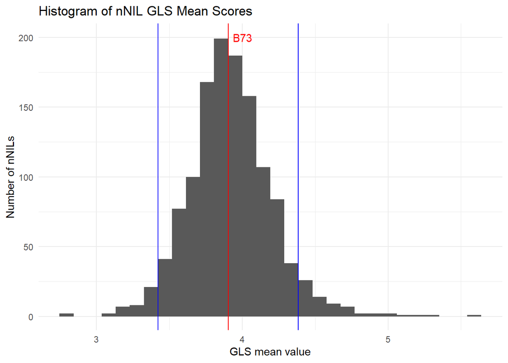

```r
(gls_hist = blues_hist("GLS", gls.blues.list))
```

# NLB

Fit random model

```r
nlbmod = rand.multi.mod("NLB", nlb)
```

```
## [1] "Geno as random effect"
## [1] "NLB"
## ASReml Version 4.2 02/04/2025 14:51:52
##           LogLik        Sigma2     DF     wall
##  1     -17543.23           1.0  10468   14:51:57
##  2     -17114.78           1.0  10468   14:51:57
##  3     -16885.62           1.0  10468   14:51:57
##  4     -16795.37           1.0  10468   14:51:57
##  5     -16766.41           1.0  10468   14:51:57
##  6     -16762.58           1.0  10468   14:51:57
##  7     -16762.43           1.0  10468   14:51:57
##  8     -16762.43           1.0  10468   14:51:57
## $call
## asreml(fixed = fixed.part, random = ~at(trait):Block:Rep:Env +
##     us(trait):Geno, residual = ~dsum(~units:us(trait) | Env),
##     data = dat, workspace = "16gb", maxiter = 50)
##
## $loglik
## [1] -16762.43
##
## $nedf
## [1] 10468
##
## $sigma
## [1] 1
##
## $varcomp
##                                 component std.error   z.ratio bound %ch
## at(trait, 'NLB1'):Block:Rep:Env  9.390337 0.9649032  9.731895     P   0
## at(trait, 'NLB2'):Block:Rep:Env 26.763323 2.6808391  9.983189     P   0
## trait:Geno!trait_NLB1:NLB1       1.431902 0.1441111  9.936096     P   0
## trait:Geno!trait_NLB2:NLB1       2.244653 0.1808025 12.414945     P   0
## trait:Geno!trait_NLB2:NLB2       3.683370 0.3430216 10.738014     P   0
## Env_NLB-2015!R                   1.000000        NA        NA     F   0
## Env_NLB-2015!trait_NLB1:NLB1     2.891294 0.1863218 15.517744     P   0
## Env_NLB-2015!trait_NLB2:NLB1     1.401174 0.3290578  4.258141     P   0
## Env_NLB-2015!trait_NLB2:NLB2    21.125363 1.0236061 20.638177     P   0
## Env_NLB-2016!R                   1.000000        NA        NA     F   0
## Env_NLB-2016!trait_NLB1:NLB1     7.675332 0.2574687 29.810739     P   0
## Env_NLB-2016!trait_NLB2:NLB1     3.626617 0.2526189 14.356080     P   0
## Env_NLB-2016!trait_NLB2:NLB2    11.632054 0.4224769 27.532994     P   0
## Env_NLB-2018!R                   1.000000        NA        NA     F   0
## Env_NLB-2018!trait_NLB1:NLB1    13.991750 0.6050640 23.124412     P   0
## Env_NLB-2018!trait_NLB2:NLB1     7.185115 0.6417733 11.195720     P   0
## Env_NLB-2018!trait_NLB2:NLB2    26.187391 1.1540789 22.691163     P   0
##
## $bic
## [1] 33654.44
## attr(,"parameters")
## [1] 14
##
## $aic
## [1] 33552.85
## attr(,"parameters")
## [1] 14
##
## attr(,"class")
## [1] "summary.asreml"
```

```r
summary(nlbmod)
```

```
## $call
## asreml(fixed = fixed.part, random = ~at(trait):Block:Rep:Env +
##     us(trait):Geno, residual = ~dsum(~units:us(trait) | Env),
##     data = dat, workspace = "16gb", maxiter = 50)
##
## $loglik
## [1] -16762.43
##
## $nedf
## [1] 10468
##
## $sigma
## [1] 1
##
## $varcomp
##                                 component std.error   z.ratio bound %ch
## at(trait, 'NLB1'):Block:Rep:Env  9.390337 0.9649032  9.731895     P   0
## at(trait, 'NLB2'):Block:Rep:Env 26.763323 2.6808391  9.983189     P   0
## trait:Geno!trait_NLB1:NLB1       1.431902 0.1441111  9.936096     P   0
## trait:Geno!trait_NLB2:NLB1       2.244653 0.1808025 12.414945     P   0
## trait:Geno!trait_NLB2:NLB2       3.683370 0.3430216 10.738014     P   0
## Env_NLB-2015!R                   1.000000        NA        NA     F   0
## Env_NLB-2015!trait_NLB1:NLB1     2.891294 0.1863218 15.517744     P   0
## Env_NLB-2015!trait_NLB2:NLB1     1.401174 0.3290578  4.258141     P   0
## Env_NLB-2015!trait_NLB2:NLB2    21.125363 1.0236061 20.638177     P   0
## Env_NLB-2016!R                   1.000000        NA        NA     F   0
## Env_NLB-2016!trait_NLB1:NLB1     7.675332 0.2574687 29.810739     P   0
## Env_NLB-2016!trait_NLB2:NLB1     3.626617 0.2526189 14.356080     P   0
## Env_NLB-2016!trait_NLB2:NLB2    11.632054 0.4224769 27.532994     P   0
## Env_NLB-2018!R                   1.000000        NA        NA     F   0
## Env_NLB-2018!trait_NLB1:NLB1    13.991750 0.6050640 23.124412     P   0
## Env_NLB-2018!trait_NLB2:NLB1     7.185115 0.6417733 11.195720     P   0
## Env_NLB-2018!trait_NLB2:NLB2    26.187391 1.1540789 22.691163     P   0
##
## $bic
## [1] 33654.44
## attr(,"parameters")
## [1] 14
##
## $aic
## [1] 33552.85
## attr(,"parameters")
## [1] 14
##
## attr(,"class")
## [1] "summary.asreml"
```

Estimate genetic variances, correlations, heritability

```r
fixed.part.nlb = as.formula("cbind(NLB1, NLB2) ~ trait + trait:Env")
(results.nlb = genvarcor("NLB", nlbmod, fixed.part.nlb, nlb))
```

```
## ASReml Version 4.2 02/04/2025 14:51:59
##           LogLik        Sigma2     DF     wall
##  1     -16762.43           1.0  10468   14:52:09
##  2     -16762.43           1.0  10468   14:52:09
##  3     -16762.43           1.0  10468   14:52:10
## ASReml Version 4.2 02/04/2025 14:52:13
##           LogLik        Sigma2     DF     wall
##  1     -17543.23           1.0  10468   14:52:23
##  2     -17114.78           1.0  10468   14:52:23
##  3     -16885.62           1.0  10468   14:52:23
##  4     -16795.37           1.0  10468   14:52:23
##  5     -16766.41           1.0  10468   14:52:23
##  6     -16762.58           1.0  10468   14:52:23
##  7     -16762.43           1.0  10468   14:52:23
##  8     -16762.43           1.0  10468   14:52:23
##  9     -16762.43           1.0  10468   14:52:23
```

```
##          Estimate         SE Parameter Trait
## rg      0.9773946 0.03879028        rg   NLB
## Vg_1    1.4319020 0.14411113      Vg_1   NLB
## Vg_2    3.6833704 0.34302157      Vg_2   NLB
## re1     0.1792850 0.03897954       re1   NLB
## re2     0.3838176 0.02101891       re2   NLB
## re3     0.3753631 0.02650131       re3   NLB
## h2_1    0.5121652         NA      h2_1   NLB
## h2_2    0.5127631         NA      h2_2   NLB
## h2_mean 0.5264477         NA   h2_mean   NLB
## h2_Cull 0.5363113         NA   h2_Cull   NLB
```

Estimate BLUEs

```r
nlb2 = nlb |>
  select(Env, Rep, Block, Geno, Plot, NLB1, NLB2) |>
  pivot_longer(cols = c("NLB1", "NLB2"), names_to = "Rating", values_to = "NLB") |>
  mutate(Rating= as.factor(Rating))
nlb.blues.list = get.blues("NLB", nlb2)
```

```
## [1] "Geno as fixed effects"
## [1] "NLB"
## ASReml Version 4.2 02/04/2025 14:52:26
##           LogLik        Sigma2     DF     wall
##  1     -17679.67           1.0   8000   14:52:33
##  2     -16562.61           1.0   8000   14:52:33
##  3     -16415.79           1.0   8000   14:52:34
##  4     -16376.41           1.0   8000   14:52:35
##  5     -16364.33           1.0   8000   14:52:36
##  6     -16362.51           1.0   8000   14:52:37  (  1 restrained)
##  7     -16362.25           1.0   8000   14:52:37  (  1 restrained)
##  8     -16362.23           1.0   8000   14:52:38  (  1 restrained)
##  9     -16362.23           1.0   8000   14:52:39  (  1 restrained)
## [1] ""
## Wald tests for fixed effects.
## Response: NLB
## Terms added sequentially; adjusted for those above.
##
##                 Df Sum of Sq Wald statistic Pr(Chisq)
## (Intercept)      1     32.11          32.11  1.46e-08 ***
## Geno          1261   2722.65        2722.65 < 2.2e-16 ***
## residual (MS)           1.00
## ---
## Signif. codes:  0 '***' 0.001 '**' 0.01 '*' 0.05 '.' 0.1 ' ' 1
## ASReml Version 4.2 02/04/2025 14:52:41
##           LogLik        Sigma2     DF     wall
##  1     -16362.23           1.0   8000   14:52:52
##  2     -16362.23           1.0   8000   14:52:53
##  3     -16362.23           1.0   8000   14:53:00
## List of 2
##  $ :Classes 'asreml.predict' and 'data.frame':   1265 obs. of  4 variables:
##   ..$ Geno               : Factor w/ 1266 levels "B73","BBP","CML103/B73 NIL-1001",..: 1 3 4 5 6 7 8 9 10 11 ...
##   ..$ NLB                : num [1:1265] 18 18.6 16 17.2 15.6 ...
##   ..$ NLB.sig.less.B73   : logi [1:1265] FALSE FALSE FALSE FALSE FALSE TRUE ...
##   ..$ NLB.sig.greater.B73: logi [1:1265] FALSE FALSE FALSE FALSE FALSE FALSE ...
##  $ :'data.frame':    4 obs. of  3 variables:
##   ..$ Trait    : chr [1:4] "NLB" "NLB" "NLB" "NLB"
##   ..$ Parameter: chr [1:4] "Mean_LSD_vs_B73" "B73_mean" "Lower_Sign_Diff" "Upper_Sign_Diff"
##   ..$ Estimate : num [1:4] 4.08 17.97 13.9 22.05
## NULL
```

```r
nlb.blues.df = nlb.blues.list[[1]]
nlb.params.df = nlb.blues.list[[2]]
```

Histogram of BLUEs

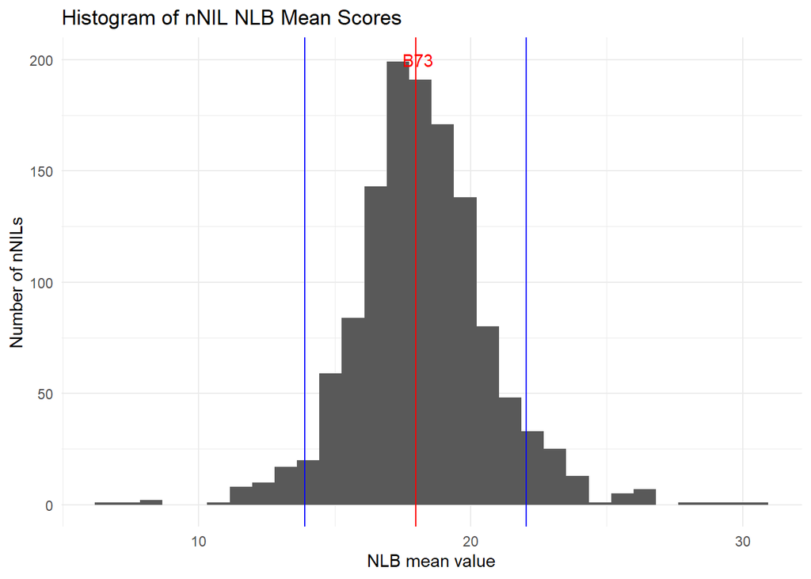

```r
(nlb_hist = blues_hist("NLB", nlb.blues.list))
```

# SLB

Fit random model

```r
slbmod = rand.multi.mod("SLB", slb)
```

```
## [1] "Geno as random effect"
## [1] "SLB"
## ASReml Version 4.2 02/04/2025 14:53:04
##           LogLik        Sigma2     DF     wall
##  1      1189.436           1.0   9852   14:53:09
##  2      1429.050           1.0   9852   14:53:09
##  3      1653.258           1.0   9852   14:53:09
##  4      1754.557           1.0   9852   14:53:09
##  5      1778.876           1.0   9852   14:53:10
##  6      1779.917           1.0   9852   14:53:10
##  7      1779.932           1.0   9852   14:53:10
##  8      1779.932           1.0   9852   14:53:10
## $call
## asreml(fixed = fixed.part, random = ~at(trait):Block:Rep:Env +
##     us(trait):Geno, residual = ~dsum(~units:us(trait) | Env),
##     data = dat, workspace = "16gb", maxiter = 50)
##
## $loglik
## [1] 1779.932
##
## $nedf
## [1] 9852
##
## $sigma
## [1] 1
##
## $varcomp
##                                  component   std.error   z.ratio bound %ch
## at(trait, 'SLB1'):Block:Rep:Env 0.07567269 0.008226765  9.198354     P   0
## at(trait, 'SLB2'):Block:Rep:Env 0.18161949 0.020030553  9.067123     P   0
## trait:Geno!trait_SLB1:SLB1      0.06818374 0.004140113 16.469053     P   0
## trait:Geno!trait_SLB2:SLB1      0.11549624 0.006195260 18.642680     P   0
## trait:Geno!trait_SLB2:SLB2      0.21210367 0.011817865 17.947715     P   0
## Env_SLB-2014!R                  1.00000000          NA        NA     F   0
## Env_SLB-2014!trait_SLB1:SLB1    0.14918539 0.005026491 29.679825     P   0
## Env_SLB-2014!trait_SLB2:SLB1    0.07604026 0.005421995 14.024406     P   0
## Env_SLB-2014!trait_SLB2:SLB2    0.20749225 0.009061790 22.897491     P   0
## Env_SLB-2015!R                  1.00000000          NA        NA     F   0
## Env_SLB-2015!trait_SLB1:SLB1    0.05862272 0.003394372 17.270563     P   0
## Env_SLB-2015!trait_SLB2:SLB1    0.02771541 0.005915476  4.685237     P   0
## Env_SLB-2015!trait_SLB2:SLB2    0.41829891 0.019301091 21.672293     P   0
## Env_SLB-2016!R                  1.00000000          NA        NA     F   0
## Env_SLB-2016!trait_SLB1:SLB1    0.26295601 0.011345259 23.177612     P   0
## Env_SLB-2016!trait_SLB2:SLB1    0.08311296 0.008952132  9.284153     P   0
## Env_SLB-2016!trait_SLB2:SLB2    0.24603742 0.012334828 19.946563     P   0
##
## $bic
## [1] -3431.128
## attr(,"parameters")
## [1] 14
##
## $aic
## [1] -3531.864
## attr(,"parameters")
## [1] 14
##
## attr(,"class")
## [1] "summary.asreml"
```

```r
summary(slbmod)
```

```
## $call
## asreml(fixed = fixed.part, random = ~at(trait):Block:Rep:Env +
##     us(trait):Geno, residual = ~dsum(~units:us(trait) | Env),
##     data = dat, workspace = "16gb", maxiter = 50)
##
## $loglik
## [1] 1779.932
##
## $nedf
## [1] 9852
##
## $sigma
## [1] 1
##
## $varcomp
##                                  component   std.error   z.ratio bound %ch
## at(trait, 'SLB1'):Block:Rep:Env 0.07567269 0.008226765  9.198354     P   0
## at(trait, 'SLB2'):Block:Rep:Env 0.18161949 0.020030553  9.067123     P   0
## trait:Geno!trait_SLB1:SLB1      0.06818374 0.004140113 16.469053     P   0
## trait:Geno!trait_SLB2:SLB1      0.11549624 0.006195260 18.642680     P   0
## trait:Geno!trait_SLB2:SLB2      0.21210367 0.011817865 17.947715     P   0
## Env_SLB-2014!R                  1.00000000          NA        NA     F   0
## Env_SLB-2014!trait_SLB1:SLB1    0.14918539 0.005026491 29.679825     P   0
## Env_SLB-2014!trait_SLB2:SLB1    0.07604026 0.005421995 14.024406     P   0
## Env_SLB-2014!trait_SLB2:SLB2    0.20749225 0.009061790 22.897491     P   0
## Env_SLB-2015!R                  1.00000000          NA        NA     F   0
## Env_SLB-2015!trait_SLB1:SLB1    0.05862272 0.003394372 17.270563     P   0
## Env_SLB-2015!trait_SLB2:SLB1    0.02771541 0.005915476  4.685237     P   0
## Env_SLB-2015!trait_SLB2:SLB2    0.41829891 0.019301091 21.672293     P   0
## Env_SLB-2016!R                  1.00000000          NA        NA     F   0
## Env_SLB-2016!trait_SLB1:SLB1    0.26295601 0.011345259 23.177612     P   0
## Env_SLB-2016!trait_SLB2:SLB1    0.08311296 0.008952132  9.284153     P   0
## Env_SLB-2016!trait_SLB2:SLB2    0.24603742 0.012334828 19.946563     P   0
##
## $bic
## [1] -3431.128
## attr(,"parameters")
## [1] 14
##
## $aic
## [1] -3531.864
## attr(,"parameters")
## [1] 14
##
## attr(,"class")
## [1] "summary.asreml"
```

Estimate genetic variances, correlations, heritability

```r
fixed.part.slb = as.formula("cbind(SLB1, SLB2) ~ trait + trait:Env")
(results.slb = genvarcor("SLB", slbmod, fixed.part.slb, slb))
```

```
## ASReml Version 4.2 02/04/2025 14:53:12
##           LogLik        Sigma2     DF     wall
##  1      1779.932           1.0   9852   14:53:22
##  2      1779.932           1.0   9852   14:53:22
##  3      1779.932           1.0   9852   14:53:22
## ASReml Version 4.2 02/04/2025 14:53:26
##           LogLik        Sigma2     DF     wall
##  1      1189.436           1.0   9852   14:53:37
##  2      1429.050           1.0   9852   14:53:37
##  3      1653.258           1.0   9852   14:53:37
##  4      1754.557           1.0   9852   14:53:37
##  5      1778.876           1.0   9852   14:53:37
##  6      1779.917           1.0   9852   14:53:37
##  7      1779.932           1.0   9852   14:53:37
##  8      1779.932           1.0   9852   14:53:37
##  9      1779.932           1.0   9852   14:53:37
```

```
##           Estimate          SE Parameter Trait
## rg      0.96040263 0.015352525        rg   SLB
## Vg_1    0.06818374 0.004140113      Vg_1   SLB
## Vg_2    0.21210367 0.011817865      Vg_2   SLB
## re1     0.43219476 0.023201723       re1   SLB
## re2     0.17698844 0.034603343       re2   SLB
## re3     0.32675830 0.028969947       re3   SLB
## h2_1    0.75960168          NA      h2_1   SLB
## h2_2    0.76929813          NA      h2_2   SLB
## h2_mean 0.77924749          NA   h2_mean   SLB
## h2_Cull 0.78078173          NA   h2_Cull   SLB
```

Estimate BLUEs

```r
slb2 = slb |>
  select(Env, Rep, Block, Geno, Plot, SLB1, SLB2) |>
  pivot_longer(cols = c("SLB1", "SLB2"), names_to = "Rating", values_to = "SLB") |>
  mutate(Rating= as.factor(Rating))
slb.blues.list = get.blues("SLB", slb2)
```

```
## [1] "Geno as fixed effects"
## [1] "SLB"
## ASReml Version 4.2 02/04/2025 14:53:40
##           LogLik        Sigma2     DF     wall
##  1     -2452.656           1.0   8007   14:53:46  (  3 restrained)
##  2     -2213.634           1.0   8007   14:53:48
##  3     -1466.949           1.0   8007   14:53:49  (  1 restrained)
##  4     -275.7788           1.0   8007   14:53:50  (  1 restrained)
##  5     -163.5143           1.0   8007   14:53:50  (  1 restrained)
##  6     -146.8388           1.0   8007   14:53:51  (  1 restrained)
##  7     -142.4161           1.0   8007   14:53:52
##  8     -140.9775           1.0   8007   14:53:53
##  9     -140.6183           1.0   8007   14:53:54
## 10     -140.5770           1.0   8007   14:53:54
## 11     -140.5761           1.0   8007   14:53:55
```

```
## [1] ""
## Wald tests for fixed effects.
## Response: SLB
## Terms added sequentially; adjusted for those above.
##
##                 Df Sum of Sq Wald statistic Pr(Chisq)
## (Intercept)      1      65.2           65.2 6.661e-16 ***
## Geno          1257    5716.9         5716.9 < 2.2e-16 ***
## residual (MS)            1.0
## ---
## Signif. codes:  0 '***' 0.001 '**' 0.01 '*' 0.05 '.' 0.1 ' ' 1
## ASReml Version 4.2 02/04/2025 14:53:57
##           LogLik        Sigma2     DF     wall
##  1     -140.5761           1.0   8007   14:54:10
##  2     -140.5761           1.0   8007   14:54:11
##  3     -140.5761           1.0   8007   14:54:17
## List of 2
##  $ :Classes 'asreml.predict' and 'data.frame':   1257 obs. of  4 variables:
##   ..$ Geno               : Factor w/ 1258 levels "B73","BBP","CML103/B73 NIL-1001",..: 1 3 4 5 6 7 8 9 10 11 ...
##   ..$ SLB                : num [1:1257] 4.55 4.09 4.03 4.22 4.22 ...
##   ..$ SLB.sig.less.B73   : logi [1:1257] FALSE FALSE FALSE FALSE FALSE TRUE ...
##   ..$ SLB.sig.greater.B73: logi [1:1257] FALSE FALSE FALSE FALSE FALSE FALSE ...
##  $ :'data.frame':    4 obs. of  3 variables:
##   ..$ Trait    : chr [1:4] "SLB" "SLB" "SLB" "SLB"
##   ..$ Parameter: chr [1:4] "Mean_LSD_vs_B73" "B73_mean" "Lower_Sign_Diff" "Upper_Sign_Diff"
##   ..$ Estimate : num [1:4] 0.546 4.547 4.001 5.092
## NULL
```

```r
slb.blues.df = slb.blues.list[[1]]
slb.params.df = slb.blues.list[[2]]
```

Histogram of BLUEs

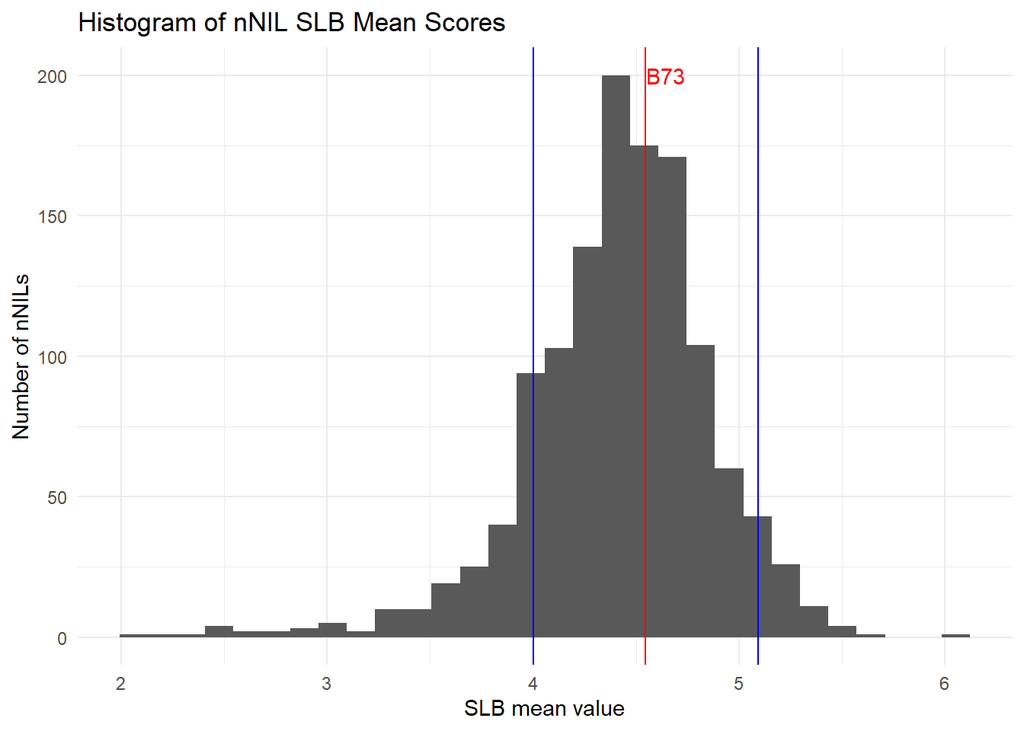

```r
(slb_hist = blues_hist("SLB", slb.blues.list))
```

# DTA, EHT, PHT

Get BLUEs for DTA, EHT, and PHT across environments. Drop environments where trait was not scored

```r
missing.env = pheno |>
  group_by(Env) |>
  summarise(nDTA = sum(!is.na(DTA)),
            nEHT = sum(!is.na(EHT)),
            nPHT = sum(!is.na(PHT)))
```

Make new pheno subsets where traits are not completely missing in some environments

```r
pheno.DTA = pheno |> filter(!grepl("GLS", Env) & !grepl("NLB-201[68]", Env))
unique(pheno.DTA$Env)
```

```
## [1] NLB-2015 SLB-2014 SLB-2015 SLB-2016
## 9 Levels: GLS-2014 GLS-2016 GLS-2017 NLB-2015 NLB-2016 NLB-2018 ... SLB-2016
```

Make new pheno subsets where traits are not completely missing in some environments

```r
pheno.HT = pheno |> filter(!grepl("GLS", Env) & !grepl("NLB-2016", Env))
unique(pheno.HT$Env)
```

```
## [1] NLB-2015 NLB-2018 SLB-2014 SLB-2015 SLB-2016
## 9 Levels: GLS-2014 GLS-2016 GLS-2017 NLB-2015 NLB-2016 NLB-2018 ... SLB-2016
```

We need a different model for these traits, as there is only one observation per plot.  
Use Rating = F argument to get.blues to not include Rating random effect in the model

```r
dta.blues.list = get.blues("DTA", pheno.DTA, Rating = F)
```

```
## [1] "Geno as fixed effects"
## [1] "DTA"
## ASReml Version 4.2 02/04/2025 14:54:21
##           LogLik        Sigma2     DF     wall
##  1     -5742.509           1.0   4125   14:54:27
##  2     -5629.096           1.0   4125   14:54:29
##  3     -5566.114           1.0   4125   14:54:30
##  4     -5550.928           1.0   4125   14:54:31
##  5     -5546.684           1.0   4125   14:54:32
##  6     -5545.672           1.0   4125   14:54:33
##  7     -5545.411           1.0   4125   14:54:33
##  8     -5545.377           1.0   4125   14:54:34
##  9     -5545.376           1.0   4125   14:54:35
## [1] ""
## Wald tests for fixed effects.
## Response: DTA
## Terms added sequentially; adjusted for those above.
##
##                 Df Sum of Sq Wald statistic Pr(Chisq)
## (Intercept)      1    844.36         844.36 < 2.2e-16 ***
## Geno          1253   2072.72        2072.72 < 2.2e-16 ***
## residual (MS)           1.00
## ---
## Signif. codes:  0 '***' 0.001 '**' 0.01 '*' 0.05 '.' 0.1 ' ' 1
## ASReml Version 4.2 02/04/2025 14:54:37
##           LogLik        Sigma2     DF     wall
##  1     -5545.376           1.0   4125   14:54:49
##  2     -5545.376           1.0   4125   14:54:50
##  3     -5545.376           1.0   4125   14:54:56
## List of 2
##  $ :Classes 'asreml.predict' and 'data.frame':   1259 obs. of  4 variables:
##   ..$ Geno               : Factor w/ 1260 levels "B73","BBP","CML103/B73 NIL-1001",..: 1 3 4 5 6 7 8 9 10 11 ...
##   ..$ DTA                : num [1:1259] 67.2 69.2 68.3 67.5 67.1 ...
##   ..$ DTA.sig.less.B73   : logi [1:1259] FALSE FALSE FALSE FALSE FALSE FALSE ...
##   ..$ DTA.sig.greater.B73: logi [1:1259] FALSE FALSE FALSE FALSE FALSE FALSE ...
##  $ :'data.frame':    4 obs. of  3 variables:
##   ..$ Trait    : chr [1:4] "DTA" "DTA" "DTA" "DTA"
##   ..$ Parameter: chr [1:4] "Mean_LSD_vs_B73" "B73_mean" "Lower_Sign_Diff" "Upper_Sign_Diff"
##   ..$ Estimate : num [1:4] 2.16 67.22 65.05 69.38
## NULL
```

```r
dta.blues.df = dta.blues.list[[1]]
dta.params.df = dta.blues.list[[2]]
```

```r
eht.blues.list = get.blues("EHT", pheno.HT, Rating = F)
```

```
## [1] "Geno as fixed effects"
## [1] "EHT"
## ASReml Version 4.2 02/04/2025 14:55:00
##           LogLik        Sigma2     DF     wall
##  1     -18654.93           1.0   6194   14:55:06
##  2     -18532.24           1.0   6194   14:55:07  (  1 restrained)
##  3     -18412.37           1.0   6194   14:55:07
##  4     -18345.57           1.0   6194   14:55:08
##  5     -18320.30           1.0   6194   14:55:09
##  6     -18317.20           1.0   6194   14:55:09
##  7     -18317.12           1.0   6194   14:55:10
##  8     -18317.12           1.0   6194   14:55:11
## [1] ""
## Wald tests for fixed effects.
## Response: EHT
## Terms added sequentially; adjusted for those above.
##
##                 Df Sum of Sq Wald statistic Pr(Chisq)
## (Intercept)      1     543.5          543.5 < 2.2e-16 ***
## Geno          1260    3655.8         3655.8 < 2.2e-16 ***
## residual (MS)            1.0
## ---
## Signif. codes:  0 '***' 0.001 '**' 0.01 '*' 0.05 '.' 0.1 ' ' 1
## ASReml Version 4.2 02/04/2025 14:55:12
##           LogLik        Sigma2     DF     wall
##  1     -18317.12           1.0   6194   14:55:23
##  2     -18317.12           1.0   6194   14:55:24
##  3     -18317.12           1.0   6194   14:55:30
## List of 2
##  $ :Classes 'asreml.predict' and 'data.frame':   1261 obs. of  4 variables:
##   ..$ Geno               : Factor w/ 1262 levels "B73","BBP","CML103/B73 NIL-1001",..: 1 3 4 5 6 7 8 9 10 11 ...
##   ..$ EHT                : num [1:1261] 68.6 70.8 63.5 48.2 56.2 ...
##   ..$ EHT.sig.less.B73   : logi [1:1261] FALSE FALSE FALSE TRUE TRUE TRUE ...
##   ..$ EHT.sig.greater.B73: logi [1:1261] FALSE FALSE FALSE FALSE FALSE FALSE ...
##  $ :'data.frame':    4 obs. of  3 variables:
##   ..$ Trait    : chr [1:4] "EHT" "EHT" "EHT" "EHT"
##   ..$ Parameter: chr [1:4] "Mean_LSD_vs_B73" "B73_mean" "Lower_Sign_Diff" "Upper_Sign_Diff"
##   ..$ Estimate : num [1:4] 9.86 68.65 58.79 78.51
## NULL
```

```r
eht.blues.df = eht.blues.list[[1]]
eht.params.df = eht.blues.list[[2]]
```

```r
pht.blues.list = get.blues("PHT", pheno.HT, Rating = F)
```

```
## [1] "Geno as fixed effects"
## [1] "PHT"
## ASReml Version 4.2 02/04/2025 14:55:33
##           LogLik        Sigma2     DF     wall
##  1     -20075.35           1.0   6198   14:55:39
##  2     -19980.71           1.0   6198   14:55:40
##  3     -19899.24           1.0   6198   14:55:40  (  1 restrained)
##  4     -19862.76           1.0   6198   14:55:41  (  1 restrained)
##  5     -19851.96           1.0   6198   14:55:42  (  1 restrained)
##  6     -19850.89           1.0   6198   14:55:42  (  1 restrained)
##  7     -19850.79           1.0   6198   14:55:43  (  1 restrained)
##  8     -19850.78           1.0   6198   14:55:44
## [1] ""
## Wald tests for fixed effects.
## Response: PHT
## Terms added sequentially; adjusted for those above.
##
##                 Df Sum of Sq Wald statistic Pr(Chisq)
## (Intercept)      1     466.1          466.1 < 2.2e-16 ***
## Geno          1260    4307.3         4307.3 < 2.2e-16 ***
## residual (MS)            1.0
## ---
## Signif. codes:  0 '***' 0.001 '**' 0.01 '*' 0.05 '.' 0.1 ' ' 1
## ASReml Version 4.2 02/04/2025 14:55:45
##           LogLik        Sigma2     DF     wall
##  1     -19850.78           1.0   6198   14:55:57
##  2     -19850.78           1.0   6198   14:55:57
##  3     -19850.78           1.0   6198   14:56:03
## List of 2
##  $ :Classes 'asreml.predict' and 'data.frame':   1261 obs. of  4 variables:
##   ..$ Geno               : Factor w/ 1262 levels "B73","BBP","CML103/B73 NIL-1001",..: 1 3 4 5 6 7 8 9 10 11 ...
##   ..$ PHT                : num [1:1261] 153 149 154 137 140 ...
##   ..$ PHT.sig.less.B73   : logi [1:1261] FALSE FALSE FALSE TRUE TRUE TRUE ...
##   ..$ PHT.sig.greater.B73: logi [1:1261] FALSE FALSE FALSE FALSE FALSE FALSE ...
##  $ :'data.frame':    4 obs. of  3 variables:
##   ..$ Trait    : chr [1:4] "PHT" "PHT" "PHT" "PHT"
##   ..$ Parameter: chr [1:4] "Mean_LSD_vs_B73" "B73_mean" "Lower_Sign_Diff" "Upper_Sign_Diff"
##   ..$ Estimate : num [1:4] 12.4 152.6 140.2 165.1
## NULL
```

```r
pht.blues.df = pht.blues.list[[1]]
pht.params.df = pht.blues.list[[2]]
```

# Merge BLUEs across traits

```r
all.blues = list(gls.blues.df, nlb.blues.df, slb.blues.df, dta.blues.df, eht.blues.df, pht.blues.df) |>
  reduce(left_join, by = "Geno")
```

Get the correlations of BLUEs across traits

```r
cor(all.blues[,c("DTA", "EHT", "PHT", "GLS", "NLB", "SLB")], use = "pairwise.complete.obs")
```

```
##              DTA         EHT          PHT         GLS         NLB         SLB
## DTA  1.000000000  0.01881538 -0.009091566 -0.05249313 -0.04360689 -0.09257692
## EHT  0.018815378  1.00000000  0.768807514 -0.22449627  0.01367238 -0.07920994
## PHT -0.009091566  0.76880751  1.000000000 -0.24391615  0.03272759 -0.04655772
## GLS -0.052493126 -0.22449627 -0.243916145  1.00000000  0.20852510  0.36197832
## NLB -0.043606893  0.01367238  0.032727591  0.20852510  1.00000000  0.19388084
## SLB -0.092576915 -0.07920994 -0.046557716  0.36197832  0.19388084  1.00000000
```

These correlations are lower than observed in diversity panels.

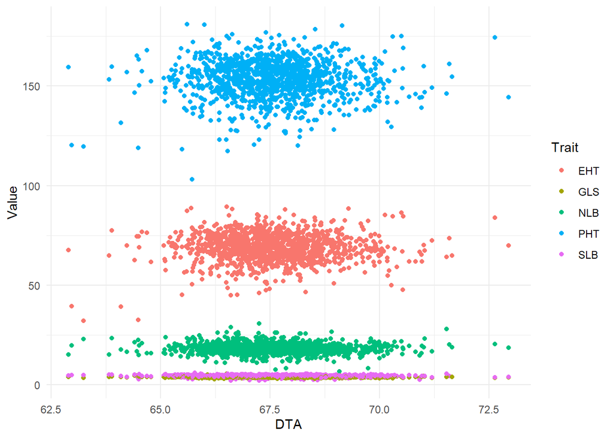

```r
all.blues.long = all.blues |>
  select(Geno, DTA, EHT, PHT, GLS, NLB, SLB) |>
  pivot_longer(cols = -c('Geno', 'DTA'), names_to = "Trait", values_to = "Value")
ggplot(all.blues.long, aes(x = DTA)) + geom_point(aes(y = Value, colour = Trait)) +
  theme_minimal()
```

Compare the different disease values against each other

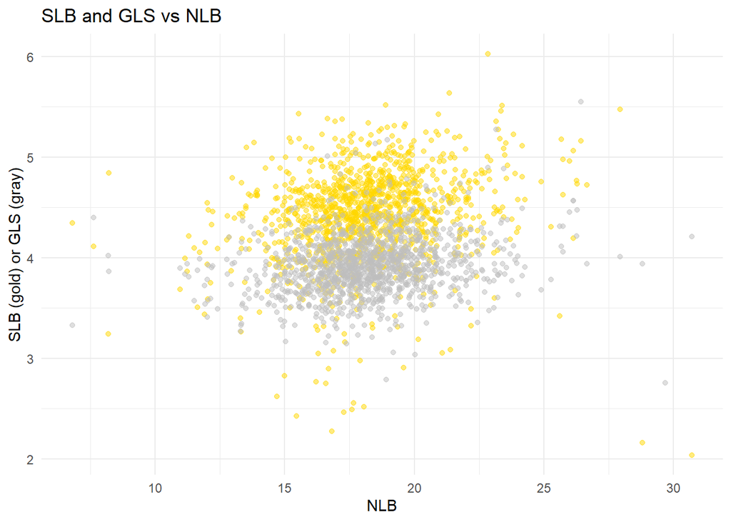

```r
ggplot(all.blues, aes(x = NLB)) +
  geom_point(aes(y = SLB), colour = "gold", alpha = 0.5) +
  geom_point(aes(y = GLS), colour = "gray", alpha = 0.5) +
  ylab('SLB (gold) or GLS (gray)') +
  ggtitle("SLB and GLS vs NLB") +
  theme_minimal()
```

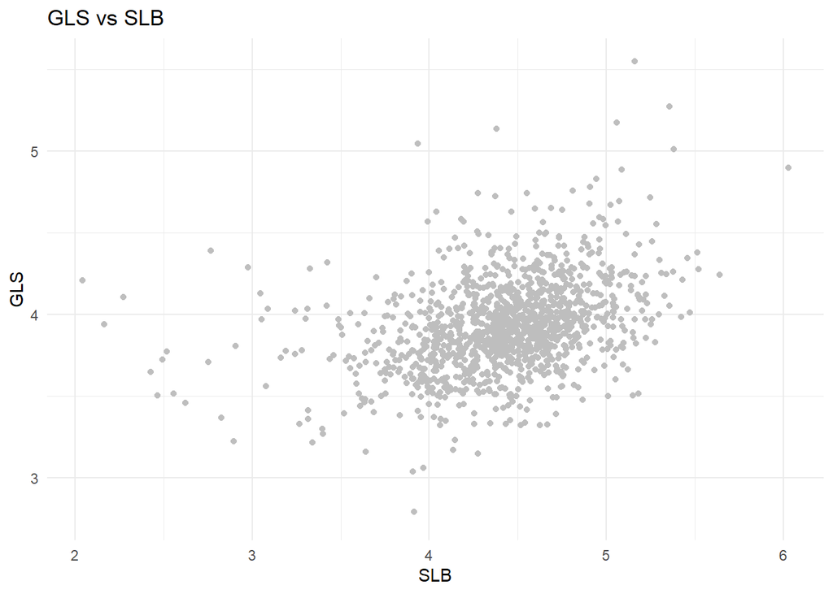

```r
ggplot(all.blues, aes(x = SLB)) +
  geom_point(aes(y = GLS), colour = "gray") +
  ggtitle("GLS vs SLB") +
  theme_minimal()
```

Write out files with BLUEs and indicator variables for extreme tails for all traits

```r
write.csv(all.blues, file = "C:/Users/jholland/Box/nNIL genotype data Jim and Tao/GWAS/nNIL_BLUEs.csv", row.names = F, quote = F)
```

Write out file with all of the summary parameter estimates

```r
all.rand.params = list(results.gls, results.nlb, results.slb) |> reduce(bind_rows)
write.csv(all.rand.params, file = "C:/Users/jholland/Box/nNIL genotype data Jim and Tao/GWAS/Trait_h2_genocorrs.csv", row.names = F, quote = F)
```

Write out file with all of the BLUEs summary values

```r
all.blues.params = list(gls.params.df, nlb.params.df, slb.params.df, dta.params.df, eht.params.df, pht.params.df) |> reduce(bind_rows)
write.csv(all.blues.params, file = "C:/Users/jholland/Box/nNIL genotype data Jim and Tao/GWAS/Trait_BLUEs_params.csv", row.names = F, quote = F)
```

Make a final figure of histograms faceted by trait all.blues.params = read.csv(“C:/Users/jholland/Box/nNIL genotype data Jim and Tao/GWAS/Trait_BLUEs_params.csv”) all.blues = read.csv(“C:/Users/jholland/Box/nNIL genotype data Jim and Tao/GWAS/nNIL_BLUEs.csv”)

```r
all.blues.long = all.blues |>
  select(-starts_with("DTA"), -starts_with("EHT"), -starts_with("PHT")) |>
  pivot_longer(col = c(GLS, NLB, SLB), names_to = "Trait", values_to = "Disease") |>
  mutate(Tail = case_when(
    Trait == "GLS" & (GLS.sig.less.B73 | GLS.sig.greater.B73) ~ T,
    Trait == "NLB" & (NLB.sig.less.B73 | NLB.sig.greater.B73) ~ T,
    Trait == "SLB" & (SLB.sig.less.B73 | SLB.sig.greater.B73) ~ T,
    T ~ F
  ))
```

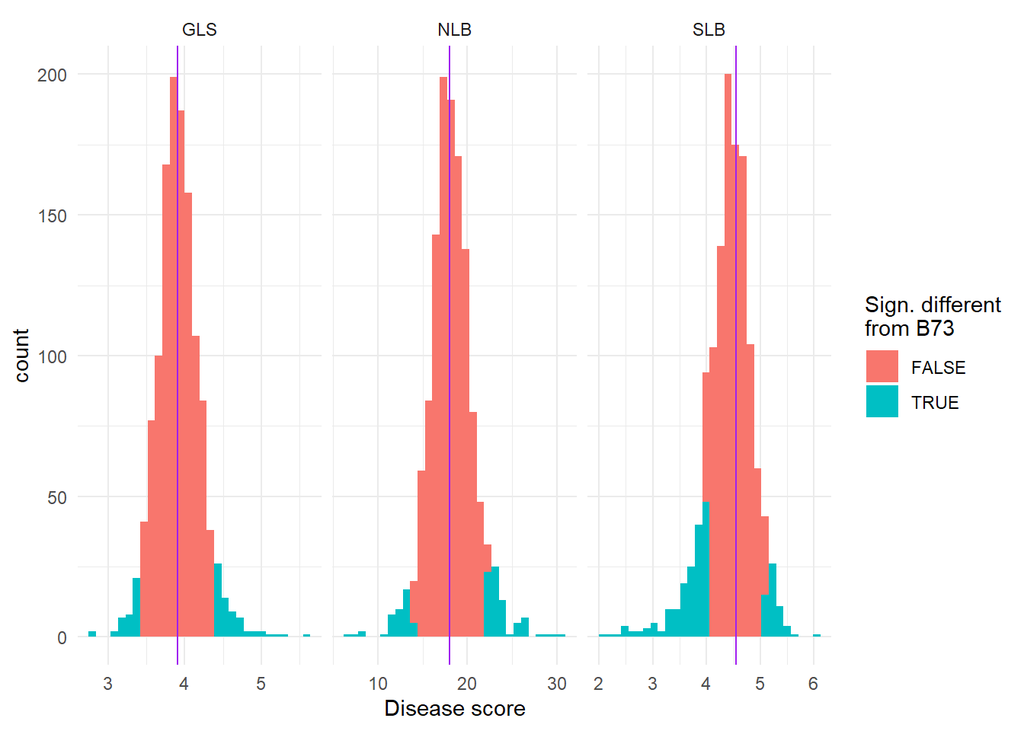

```r
ggplot(all.blues.long, aes(x = Disease)) +
  geom_histogram(aes(fill = Tail)) +
  facet_wrap(facets = ~ Trait, scales = "free_x") +
  geom_vline(data = all.blues.long[all.blues.long$Geno == "B73",], aes(xintercept = Disease), color = "purple") +
  labs(x = "Disease score", fill = "Sign. different\nfrom B73") +
  theme_minimal()
```

```r
ggsave("C:/Users/jholland/Box/nNIL genotype data Jim and Tao/GWAS/Disease_histograms.tiff",
        width = 10, height = 8, units = "in", bg = "white")
```